# Análisis estadístico de datos de Microbioma con R

### Análisis restringido de coordenadas principales (CAP)

CAP (también llamado análisis restringido de proximidades en el paquete `vegan`), es un método de ordenación similar a RDA. Es simplemente un *análisis de redundancia de los resultados del análisis de coordenadas principales (o escalamiento multidimensional métrico)* (Anderson y Willis 2003). CAP permite índices de disimilitud no euclidianos, como la distancia Manhattan o Bray-Curtis. Si se especifica la distancia euclidiana como método de ordenación, los resultados serán idénticos a los de RDA.

La función `capscale()` del paquete `vegan` se utiliza para implementar CAP. Necesita una matriz de disimilitud como conjunto de datos de entrada, que puede calcularse mediante las funciones `vegdist()`, `dist()`, o cualquier otro método que produzca matrices de similitud. Se necesitan dos pasos necesarios: primero, utilizar la función `cmdscale()` para ordenar la matriz de disimilitud, luego utilizar RDA para analizar estos resultados. A diferencia de RDA, en el que se pueden utilizar tanto la matriz como la la función `capscale()` sólo se puede llamar con la sintaxis de la fórmula. A continuación se muestra un uso de la función `capscale()`.

`capscale(formula, data, distance = "bray", dfun = vegdist)`

donde, formula es una fórmula típica del modelo como se define en `rda()` y `cca()`. El lado izquierdo de la fórmula debe ser una matriz de datos de la comunidad (marco) o una matriz de disimilitud que puede estimarse con la función `vegdist()` o `dist()`. Si el lado izquierdo de la fórmula es una matriz de datos (datframe) en lugar de una matriz de disimilitud, entonces se debe proporcionar un índice de disimilitud (o distancia). El lado derecho de la fórmula define las restricciones. Las variables de restricción pueden ser variables continuas, factores, términos de interacción o una condición de término especial utilizada para definir las variables que se van a particionar. Los datos son un data frame que contiene las variables del lado derecho de la fórmula del modelo. La función *dfun* es la función de distancia o función de disimilitud utilizada.

El CAP básico se puede realizar con los siguientes códigos. Las variables de restricción incluyen dos variables binarias (`SmokingStatus` y `Sex`), y dos variables continuas (`PackYears` y `Age`). La condición de término especial (`Age`) se utiliza para particionar el efecto de la edad.

```r
throat_meta <- select(throat.meta, SmokingStatus, Age, Sex, PackYears)
throat_cap <- capscale(throat.otu.tab ~ SmokingStatus + Sex + PackYears + Condition(Age), throat_meta,
                       dist="bray")
throat_cap
```

```
## Call: capscale(formula = throat.otu.tab ~ SmokingStatus + Sex +
## PackYears + Condition(Age), data = throat_meta, distance = "bray")
##
##               Inertia Proportion Rank
## Total         14.0932     1.0000
## Conditional    0.2084     0.0148    1
## Constrained    1.2623     0.0896    3
## Unconstrained 13.0648     0.9270   46
## Imaginary     -0.4425    -0.0314   13
## Inertia is squared Bray distance
## Species scores projected from 'throat.otu.tab'
##
## Eigenvalues for constrained axes:
##  CAP1  CAP2  CAP3
## 0.731 0.376 0.155
##
## Eigenvalues for unconstrained axes:
##  MDS1  MDS2  MDS3  MDS4  MDS5  MDS6  MDS7  MDS8
## 2.278 1.994 1.144 0.925 0.749 0.615 0.534 0.473
## (Showing 8 of 46 unconstrained eigenvalues)
```

```r
set.seed(123)
anova1 <- anova(throat_cap)
p_valor1 <- anova1$`Pr(>F)`

anova1 %>% kbl(booktabs = TRUE, align = "c",
    caption = "ANOVA test")%>%
  kable_styling(position = "center",
                latex_options = c("hold_position",  "striped"),
                font_size = 12)
```

ANOVA test

|  | Df | SumOfSqs | F | Pr(>F) |
| --- | --- | --- | --- | --- |
| Model | 3 | 1.262 | 1.771 | 0.007 |
| Residual | 55 | 13.065 | NA | NA |

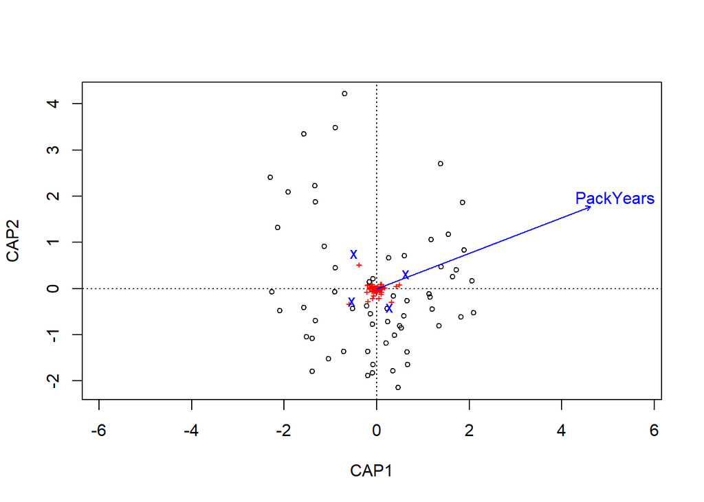

Plot básico de CAP en los datos de fumadores.

```r
plot(throat_cap)
```

Como estamos interesados en las diferentes disimilitudes entre los fumadores y los no fumadores, vamos a extraer la información del grupo.

```r
groups <- throat.meta$SmokingStatus
groups
```

```
##  [1] NonSmoker Smoker    Smoker    Smoker    Smoker    Smoker    NonSmoker
##  [8] NonSmoker NonSmoker NonSmoker Smoker    NonSmoker NonSmoker Smoker
## [15] NonSmoker Smoker    Smoker    NonSmoker NonSmoker NonSmoker NonSmoker
## [22] NonSmoker NonSmoker NonSmoker NonSmoker NonSmoker NonSmoker NonSmoker
## [29] NonSmoker NonSmoker NonSmoker NonSmoker NonSmoker Smoker    NonSmoker
## [36] NonSmoker NonSmoker NonSmoker NonSmoker Smoker    NonSmoker Smoker
## [43] NonSmoker Smoker    Smoker    Smoker    Smoker    Smoker    Smoker
## [50] Smoker    Smoker    Smoker    Smoker    Smoker    Smoker    Smoker
## [57] Smoker    NonSmoker Smoker    Smoker
## Levels: NonSmoker Smoker
```

En el siguiente grupo de códigos R, la función `plot()` genera un diagrama de ordenación CAP vacío; la función `points()` añade puntos al diagrama de ordenación (función de trazado de bajo nivel) creado por la función plot. La función `ordispider()` crea spiderplot conectando los miembros individuales del grupo con el centroide del grupo. La función `ordiellipse()` rodea las nubes de puntos dentro del grupo mediante una elipse como las envolventes.

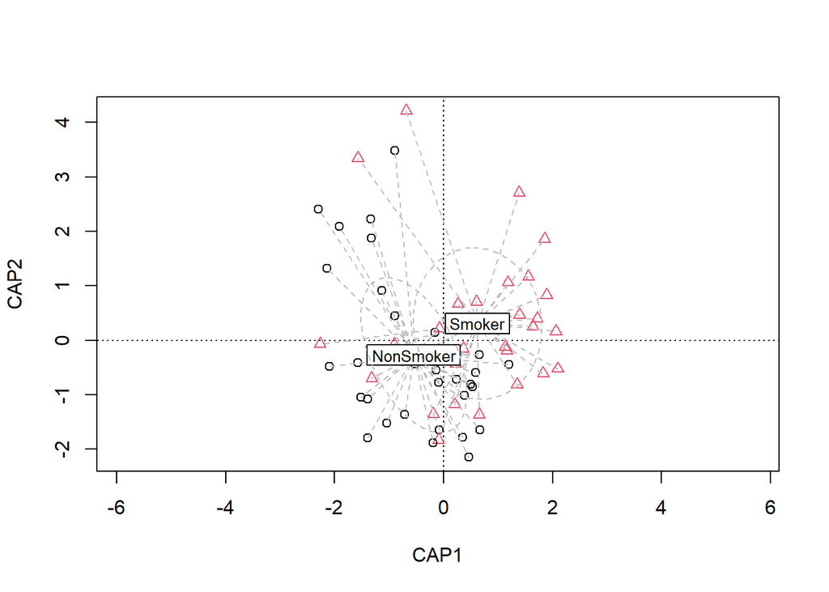

```r
# Correr todo junto
plot(throat_cap, type="n")
points(throat_cap, col=as.numeric(as.factor(groups)),
       pch=as.numeric(as.factor(groups)))
ordispider(throat_cap, groups, lty=2, col="grey", label=T)
ordiellipse(throat_cap, groups, lty=2, col="grey", label=F)
```

Al igual que en RDA y CCA, vamos a realizar una prueba de permutación para el modelo global global, cada eje y cada variable explicativa. Para asegurarse de obtener el mismo resultado de la prueba de permutación cada vez que se ejecute, establezca la misma semilla.

```r
set.seed (123)
anova_global <- anova(throat_cap, step=1000)
pvalue_global <- anova_global$`Pr(>F)`

anova_global %>% kbl(booktabs = TRUE, align = "c",
    caption = "ANOVA test global")%>%
  kable_styling(position = "center",
                latex_options = c("hold_position",  "striped"),
                font_size = 12)
```

ANOVA test global

|  | Df | SumOfSqs | F | Pr(>F) |
| --- | --- | --- | --- | --- |
| Model | 3 | 1.262 | 1.771 | 0.007 |
| Residual | 55 | 13.065 | NA | NA |

```r
set.seed (123)
anova_ejes <- anova(throat_cap, by="axis", step=1000)
pvalue_CA1 <- anova_ejes$`Pr(>F)`[1]
pvalue_CA2 <- anova_ejes$`Pr(>F)`[2]

anova_ejes %>%
  kbl(booktabs = TRUE, align = "c",
    caption = "ANOVA test por ejes")%>%
  kable_styling(position = "center",
                latex_options = c("hold_position",  "striped"),
                font_size = 12)
```

ANOVA test por ejes

|  | Df | SumOfSqs | F | Pr(>F) |
| --- | --- | --- | --- | --- |
| CAP1 | 1 | 0.7308 | 3.0763 | 0.014 |
| CAP2 | 1 | 0.3764 | 1.5844 | 0.236 |
| CAP3 | 1 | 0.1552 | 0.6535 | 0.871 |
| Residual | 55 | 13.0648 | NA | NA |

```r
set.seed (123)
anova_varibales <- anova(throat_cap, by="terms", step=1000)
pvalue_SmockingStatus <- anova_varibales$`Pr(>F)`[1]
pvalue_Sex <- anova_varibales$`Pr(>F)`[2]

anova_varibales %>%
  kbl(booktabs = TRUE, align = "c",
    caption = "ANOVA test por variables explicativas")%>%
  kable_styling(position = "center",
                latex_options = c("hold_position",  "striped"),
                font_size = 12)
```

ANOVA test por variables explicativas

|  | Df | SumOfSqs | F | Pr(>F) |
| --- | --- | --- | --- | --- |
| SmokingStatus | 1 | 0.6305 | 2.6544 | 0.002 |
| Sex | 1 | 0.4438 | 1.8683 | 0.033 |
| PackYears | 1 | 0.1880 | 0.7914 | 0.697 |
| Residual | 55 | 13.0648 | NA | NA |

Podemos ver que tanto `SmokingStatus` como `Sex` son significativos con $p-$valores de 0.002 y 0.033 respectivamente.

Ahora, hagamos la selección hacia delante utilizando la función `ordistep()` del paquete `vegan`. Como dijimos en RDA y CCA, la función compara las variables basándose en el criterio AIC y los $p-$valores de la prueba de permutación de Monte Carlo.

```r
step_forward <- ordistep(capscale(throat.otu.tab ~ 1, data=throat_meta),
                         scope=formula(throat_cap), direction="forward", pstep=1000)
```

```
##
## Start: throat.otu.tab ~ 1
##
##                  Df AIC    F Pr(>F)
## + SmokingStatus   1 712 2.05   0.06 .
## + Sex             1 712 1.68   0.09 .
## + PackYears       1 712 1.27   0.26
## + Condition(Age)  1 713 0.00
## ---
## Signif. codes:  0 '***' 0.001 '**' 0.01 '*' 0.05 '.' 0.1 ' ' 1
```

```r
# Seleccionamos la variable de Smoking status, el modelo final es ajustado como sigue
cap_final<- capscale(throat.otu.tab ~ SmokingStatus, throat_meta, dist="bray")
set.seed(123)
anova_M <- anova(cap_final, step=1000)
p_valueM <- anova_M$`Pr(>F)`

anova_M %>%
  kbl(booktabs = TRUE, align = "c",
    caption = "ANOVA test")%>%
  kable_styling(position = "center",
                latex_options = c("hold_position",  "striped"),
                font_size = 12)
```

ANOVA test

|  | Df | SumOfSqs | F | Pr(>F) |
| --- | --- | --- | --- | --- |
| Model | 1 | 0.6533 | 2.729 | 0.002 |
| Residual | 58 | 13.8823 | NA | NA |

# Resumen y discusión

Utilizamos conjuntos de datos de ratones y humanos para ilustrar el análisis exploratorio de los datos del microbioma. En primer lugar, utilizamos el paquete `phyloseq` para ilustrar los cinco gráficos, incluyendo la riqueza, la barra de abundancia, el mapa de calor, la red y el árbol filogenético. A continuación, introdujimos varias familias de *métodos de agrupación* disponibles en los estudios de ecología y microbioma, y nos centramos en ilustrar cuatro métodos de agrupación (*aglomerativo de enlace único*, *aglomerativo de enlace completo*, *aglomerativo de tinta media* y *aglomerativo de varianza mínima de Ward*). También describimos brevemente la relación entre clustering, ordenación y medida de distancia. Por último, ilustramos las *ordenaciones* más comunes *sin restricciones* y *con restricciones*: **PCA**, **PCoA**, **NMDS**, **CA**, **RDA**, **CCA** y **CAP**. Las características de las ordenaciones no restringidas se consideran “exploratorias”. Sin embargo, las capacidades de las ordenaciones restringidas van más allá del mero análisis exploratorio de datos, y se convierten también en pruebas de hipótesis. Hemos introducido las diferentes características de las ordenaciones no restringidas y restringidas.

Ilustramos el análisis exploratorio y la prueba de hipótesis (en términos de ordenaciones restringidas) de los datos del microbioma mediante el uso del paquete para analizar los datos del censo del microbioma `phyloseq` y los paquetes que comúnmente se utilizan en ecología, como el paquete `vegan`. Las funciones de extensión, es decir `cleanplot.pca()` y `evplot()` son atractivas y dos criterios para evaluar el rendimiento de las ordenaciones (el criterio de *Kaiser-Guttman* y el modelo *broken-stick*) son útiles para evaluar los análisis de ordenación.